# Data Visualization - hands-on

Python has mny add-on libraries for making static or dynamic visualizations, but will focus on:

[figure not shown]

- Matplotlib is a comprehensive library for creating static, interactive, and animated visualizations in Python.
- It serves as the basis for more specialized libraries such as Seaborn and Pandas plotting

[figure not shown]

- Based on Matplotlib that provides a **high-level interface** for drawing attractive and informative statistical graphics.

### Matplotlib Object Hierarchy:

[figure not shown]

- A **Figure** object is the outermost container for a matplotlib graphic, which can contain multiple Axes objects. One source of confusion is the name: an Axes actually translates into what we think of as an individual plot or graph (rather than the plural of “axis,” as we might expect).
- **Axes**: the actual plots
- Smaller objects such as tick marks, individual lines, legends, and text boxes.

```
array([[<Axes: >, <Axes: >, <Axes: >],
       [<Axes: >, <Axes: >, <Axes: >]], dtype=object)
```

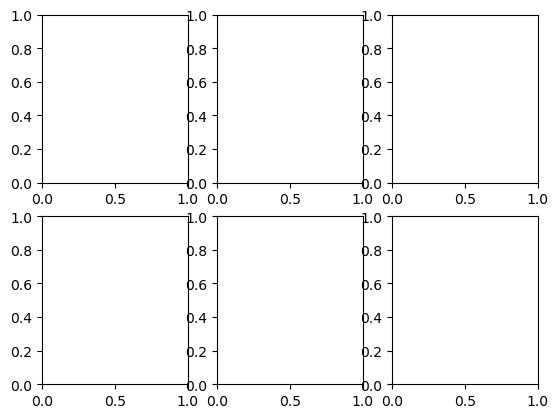

```python
import matplotlib.pyplot as plt
fig, axes = plt.subplots(2, 3)
axes
```

### Create first plot

```python
import numpy as np
data = np.random.standard_normal(30).cumsum()
data[:10]
```

```
array([-2.33669142, -1.65042042, -0.11951624,  0.29966236,  0.58489135,
        1.41668467,  1.77966819,  2.28160376,  2.27045329,  3.36295798])
```

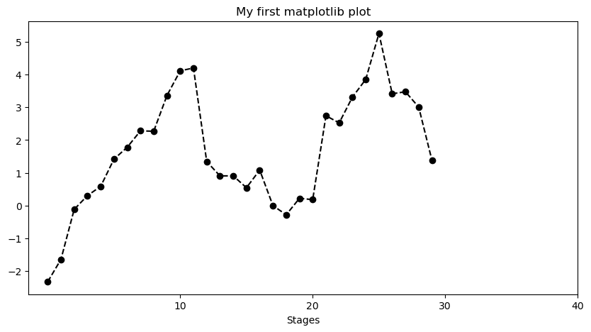

```python
import numpy as np
fig, axes = plt.subplots(figsize=(10, 5))

# axes.plot(data)

#Change style
# axes.plot(data, color="black", linestyle='dashed');
axes.plot(data, color="black", linestyle='dashed', marker="o");

# #Set axis label
axes.set_xlabel("Stages")

# # Change ticks
axes.set_xticks([10, 20, 30, 40]);

# # Set plot title
axes.set_title("My first matplotlib plot");

#Change figure size
#figsize=(10, 10)
```

#### Legends

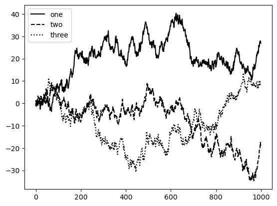

```python
#Legends
fig, ax = plt.subplots()
ax.plot(np.random.randn(1000).cumsum(), color="black", label="one");
ax.plot(np.random.randn(1000).cumsum(), color="black", linestyle="dashed", label="two");
ax.plot(np.random.randn(1000).cumsum(), color="black", linestyle="dotted", label="three");

# Add legend
ax.legend()
```

### Save figure to file

```python
# Saving to file
fig.savefig("figpath.png" )
```

### Matplotlib global configuration

- Default behavior can be customized via global parameters governing figure size, subplot spacing, colors, font sizes, grid styles, and so on.

```python
plt.rc("figure", figsize=(10, 6))
```

- The first argument to rc is the component you wish to customize, such as "figure", "axes", "xtick", "ytick", "grid", "legend", or many others.

```python
plt.rc("font", family="monospace", weight="bold", size=10)
```

### Plotting with Pandas

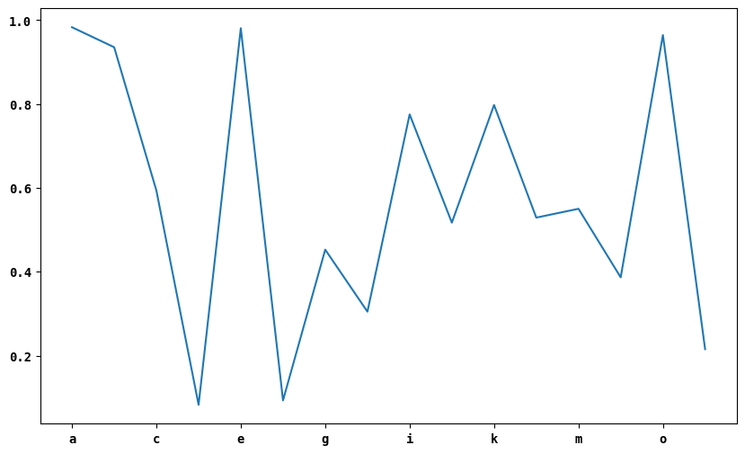

```python
import pandas as pd
data = pd.Series(np.random.uniform(size=16), index=list("abcdefghijklmnop"))
data.plot()
# data
```

### How to use matplotloib functions ?

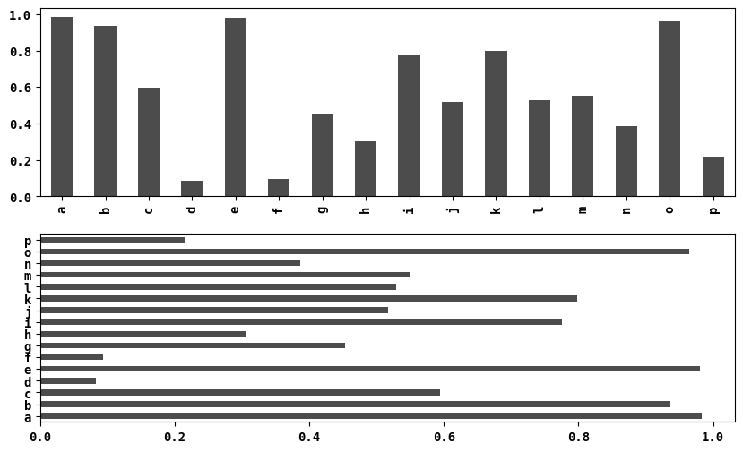

```python
fig, axes = plt.subplots(2, 1)
data.plot.bar(ax=axes[0], color="black", alpha=0.7)
data.plot.barh(ax=axes[1], color="black", alpha=0.7)
```

### Histogram

```python
sec_1 = pd.read_csv('section_1.csv').drop(columns=['Student ID']).rename(columns=lambda x: x.strip())
sec_1['Section'] = 1
sec_2 = pd.read_csv('section_2.csv').drop(columns=['Student ID']).rename(columns=lambda x: x.strip())
sec_2['Section'] = 2
df = pd.concat([sec_1, sec_2]).reset_index().drop(columns='index')
# df['Mid'] = df['Mid'].replace(" ",np.nan).astype('float')
df['Ass.1'] = df['Ass.1'] * 20
df['Ass.2'] = df['Ass.2'] * 10
df['Ass.3'] = df['Ass.3'] * 10
df['Ass.4'] = df['Ass.4'] * 10
df['Ass.5'] = df['Ass.5'] * 10
df['Q 1'] = df['Q 1'] * 3.3


df.head(5)

df['Mid'] = df['Mid'].replace(' ', np.nan).astype(float)
df.info()
```

```
<class 'pandas.core.frame.DataFrame'>
RangeIndex: 107 entries, 0 to 106
Data columns (total 8 columns):
 #   Column   Non-Null Count  Dtype
---  ------   --------------  -----
 0   Ass.1    107 non-null    float64
 1   Ass.2    107 non-null    float64
 2   Ass.3    107 non-null    float64
 3   Ass.4    107 non-null    float64
 4   Ass.5    107 non-null    float64
 5   Q 1      107 non-null    float64
 6   Mid      102 non-null    float64
 7   Section  107 non-null    int64
dtypes: float64(7), int64(1)
memory usage: 6.8 KB
```

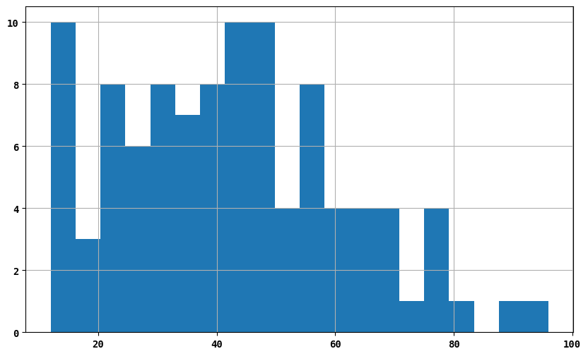

```python
df['Mid'].hist(bins=20);
```

```python
#Change bins, x ticks, label
```

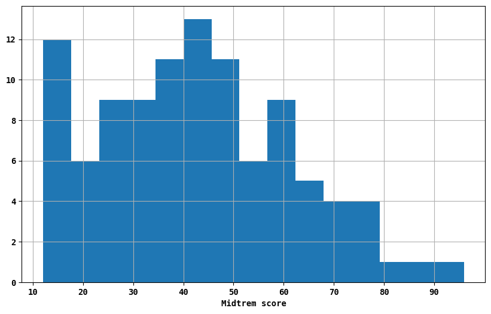

```python
fig, axes = plt.subplots()
df['Mid'].hist(ax = axes, bins=15);
axes.set_xlabel('Midtrem score')
axes.set_xticks(np.arange(10,100,10));
```

### Plot using seaborn

```python
import numpy as np
sec_1['Mid'] = sec_1['Mid'].replace(" ", np.nan).astype(float)
```

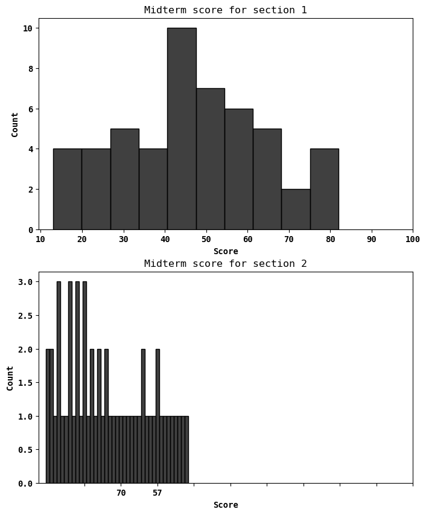

```python
import seaborn as sns
fig, axes = plt.subplots(2,1, figsize=(8,10))
sns.histplot(ax=axes[0], data=sec_1['Mid'], bins=10, color="black");
axes[0].set_title("Midterm score for section 1");
axes[0].set_xticks(np.arange(10,110,10));
axes[0].set_xlabel("Score");
sns.histplot(ax =axes[1], data=sec_2['Mid'], bins=10, color="black");
axes[1].set_title("Midterm score for section 2");
axes[1].set_xticks(np.arange(10,110,10));
axes[1].set_xlabel("Score");
```

Note that it has created labels automatically

### Plot histogram for each section and compare them?

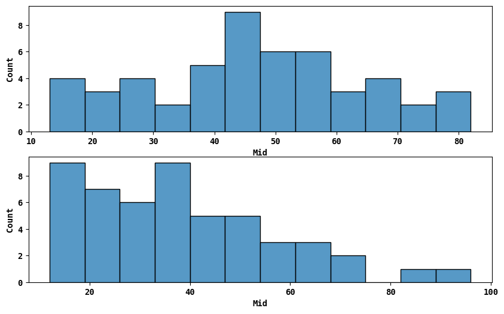

```python
fig, axes = plt.subplots(2, 1)
sec_1 = df[df['Section'] == 1]
sec_2 = df[df['Section'] == 2]
sns.histplot(ax = axes[0], data=sec_1, x = 'Mid', bins=12)
sns.histplot(ax = axes[1], data=sec_2, x = 'Mid', bins=12)
```

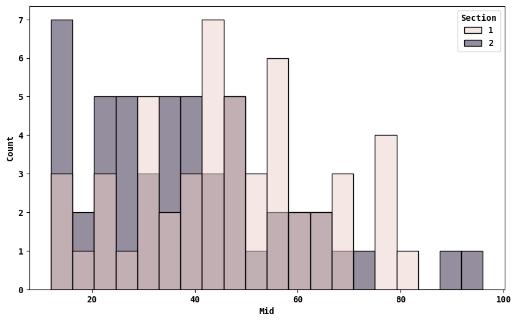

```python
sns.histplot(data = df, x = 'Mid', hue='Section',  bins=20);
```

### Scatter plot

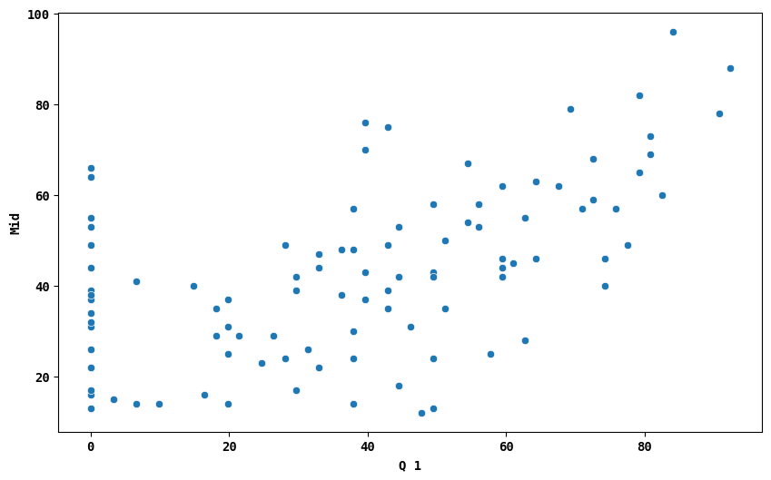

```python
sns.scatterplot(data=df, x = "Q 1", y = "Mid");
```

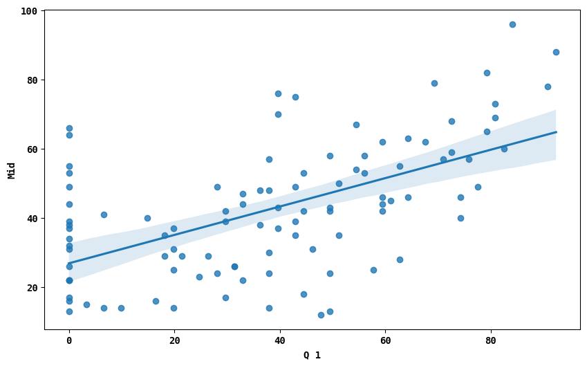

```python
# Regression plot
# df['Mid'] = df['Mid'].replace(" ",np.nan).astype('float')
sns.regplot(data=df, x = "Q 1", y = "Mid");
```

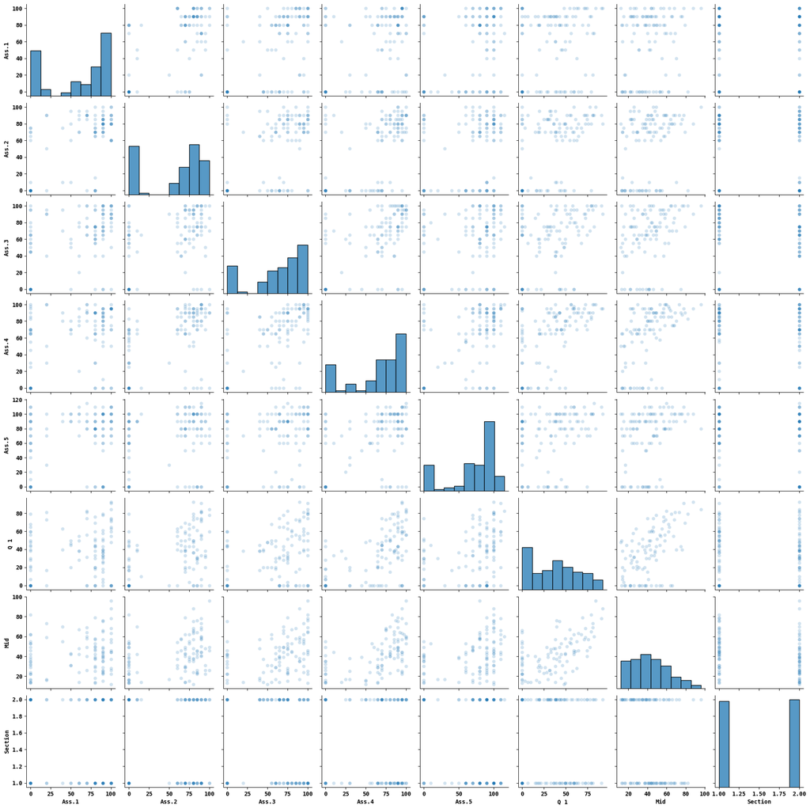

```python
sns.pairplot(df, plot_kws={"alpha": 0.2})
```

### Boxplot

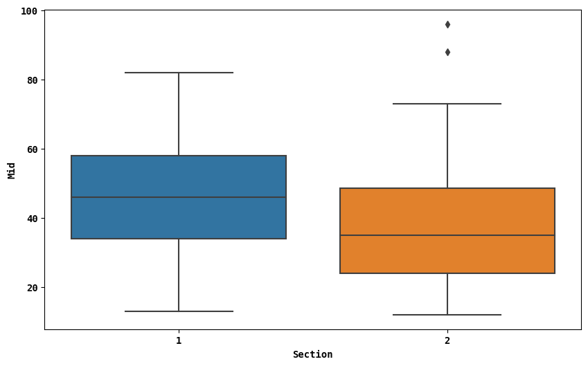

```python
sns.boxplot(data=df, x = 'Section', y='Mid')
#set x to Section
```

## Heatmap

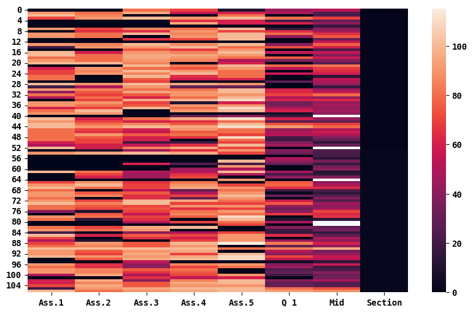

```python
sns.heatmap(data=df)
```

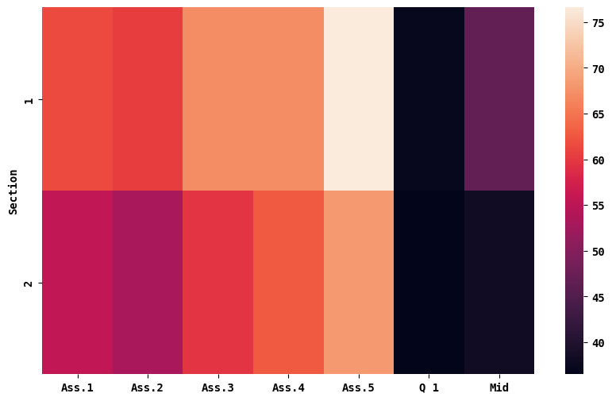

```python
sns.heatmap(df.groupby('Section').mean())
```

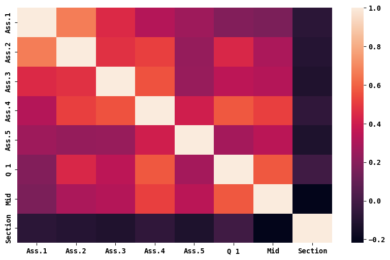

```python
sns.heatmap(df.corr())
```